# Formulaire

[inesss v.0.1.1.9000](https://github.com/INESSS-QC/inesss1)

# 1 Démarrer le formulaire

À partir de *RStudio*, cliquer sur *Addins*, puis sur *Formulaire*.

[figure not shown]

# 2 Connexion

Établir une connexion entre *R* et *Teradata*.

1. Inscrire le nom d’utilisateur (commence généralement par *MS*) ainsi que le mot de passe.
2. Cliquer sur le bouton *Connexion* pour établir la connexion. S’il n’y a pas d’erreur, le mot *Connexion* suivi de la date et l’heure sera affiché. Modifier l’identifiant ou le mot de passe au besoin.

**Attention :** Si le mot de passe est expiré, une fenêtre demandant un nouveau mot de passe apparaîtra **en arrière plan**. Sélectionner cette fenêtre à partir de la barre des tâches, puis entrer le nouveau mot de passe.

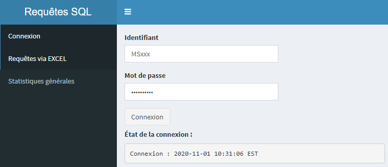

# 3 Requêtes via EXCEL

Exécution d’une ou plusieurs requêtes par l’intermédiaire d’un fichier EXCEL. Chaque onglet correspond à un tableau contenant les arguments d’une méthode.  
Pour éviter des erreurs de structure, il est conseillé d’utiliser les gabarits disponibles à partir du fichier *Gabarits-formulaire.xlsx*.

1. Cliquer sur le bouton *Sélectionner fichier EXCEL* pour sélectionner le fichier EXCEL contenant la ou les requêtes à exécuter.
2. Le programme vérifie si chaque onglet contient un tableau et si sa structure correspond à une méthode existante.
3. Si la structure est acceptée, le message `Aucune erreur, exécution possible.` s’affiche. Sinon, le message affiche toutes les erreurs à corriger, regroupés par onglet.
4. Si la structure est acceptée, le bouton *Exécuter requêtes* apparaît. Ce bouton permet de sélectionner un répertoire et le nom du fichier à sauvegarder. Lorsque c’est fait, le programme exécute la requête associé aux arguments de chaque onglet. Un message en bas à droite indique que l’exécution est en cours et disparaît lorsque c’est terminé.
5. Le fichier sauvegardé présente les résultats de la manière suivante :
   - Les onglets possèdent le même nom que ceux du fichier initial contenant les arguments.
   - À gauche se trouve le tableau des résultats.
   - Au milieu, le tableau rappelant les arguments utilisés.
   - À droite, un exemple de code SQL, celui de la première période d’analyse, utilisé dans Teradata pour créer le tableau des résultats.

## 3.1 Statistiques générales

Statistiques tiré de la vue *V_DEM_PAIMT_MED_CM*.

### 3.1.2 Résultats

#### 3.1.2.1 Tableau des résultats

- **`DATE_DEBUT` :** Indique la date de début de la période d’étude.
- **`DATE_FIN` :** Indique la date de fin de la période d’étude.
- **`DENOM / DIN` :** Code(s) analysé(s) à l’intérieur de la période d’étude. Si les résultats sont groupés par période d’étude, cette colonne se situera à la fin du tableau.
- **`NOM_DENOM / NOM_MARQ_COMRC` :** Indique le nom de la dénomination commune si c’est un `DENOM` ou le nom de la marque de commerce si c’est un `DIN`.
- **`MNT_MED` :** Montant autorisé par la RAMQ pour le médicament ou le produit. Il comprend la part du grossiste (s’il y a lieu) et la part du manufacturier (`sum(SMED_MNT_AUTOR_MED) as MNT_MED`).
- **`MNT_SERV` :** Montant de frais de service autorisé par la RAMQ à la date du service (`sum(SMED_MNT_AUTOR_FRAIS_SERV) as MNT_SERV`).
- **`MNT_TOT` :** Somme des variables `MNT_MED` et `MNT_SERV`.
- **`COHORTE` :** Nombre d’individus unique (`count(distinct SMED_NO_INDIV_BEN_BANLS) as COHORTE`).
- **`NBRE_RX` :** Nombre de demandes de paiement (`count(*) as NBRE_RX`).
- **`QTE_MED` :** Quantité totale des médicaments ou des fournitures dispensés (`sum(SMED_QTE_MED) as QTE_MED`).
- **`DUREE_TX` :** Durée de traitement totale des prescriptions en jours.

#### 3.1.2.3 Code SQL

Exemple de code SQL généré par les arguments. S’il y a plusieurs périodes d’étude, seul le code de la première période est affichée.

### 3.1.3 Exemple 1 - DENOM

**Arguments :**

| METHODE | DATE_DEBUT | DATE_FIN | TYPE_RX | CODE_RX | GROUPER_PAR | CODE_SERV_FILTRE | CODE_SERV | CODE_LIST_FILTRE | CODE_LIST |
| --- | --- | --- | --- | --- | --- | --- | --- | --- | --- |
| stat_gen1 | 2018-01-01 | 2018-12-31 | DENOM | 39 |  | Exclusion | 1 | Inclusion |  |
|  | 2019-01-01 | 2019-12-31 |  | 47092 |  |  | AD |  |  |
|  |  |  |  | 47135 |  |  |  |  |  |

**Résultats :**

| DATE_DEBUT | DATE_FIN | DENOM | NOM_DENOM | MNT_MED | MNT_SERV | MNT_TOT | COHORTE | NBRE_RX | QTE_MED | DUREE_TX |  |  |  | METHODE | DATE_DEBUT | DATE_FIN | TYPE_RX | CODE_RX | GROUPER_PAR | CODE_SERV_FILTRE | CODE_SERV | CODE_LIST_FILTRE | CODE_LIST |  |  |  | Requête SQL |
| --- | --- | --- | --- | --- | --- | --- | --- | --- | --- | --- | --- | --- | --- | --- | --- | --- | --- | --- | --- | --- | --- | --- | --- | --- | --- | --- | --- |
| 2018-01-01 | 2018-12-31 | 39 | acétaminophène | 4298016.11 | 21154864.49 | 25452880.6 | 409770 | 3400521 | 277405408.73 | 42559050 |  |  |  | stat_gen1 | 2018-01-01 | 2018-12-31 | DENOM | 39 |  | Exclusion | 1 | Inclusion |  |  |  |  | select ‘2018-01-01’ as DATE_DEBUT, |
| 2018-01-01 | 2018-12-31 | 47092 | bézafibrate | 576893.95 | 126665.06 | 703559.01 | 1247 | 17827 | 360738 | 362826 |  |  |  |  | 2019-01-01 | 2019-12-31 |  | 47092 |  |  | AD |  |  |  |  |  | ‘2018-12-31’ as DATE_FIN, |
| 2018-01-01 | 2018-12-31 | 47135 | losartan potassique | 1726132.64 | 3107241.74 | 4833374.38 | 30477 | 446844 | 8892671 | 8606603 |  |  |  |  |  |  |  | 47135 |  |  |  |  |  |  |  |  | SMED_COD_DENOM_COMNE as DENOM, |
| 2019-01-01 | 2019-12-31 | 39 | acétaminophène | 4367669.26 | 21824141.97 | 26191811.23 | 419983 | 3502574 | 282496091.79 | 43238057 |  |  |  |  |  |  |  |  |  |  |  |  |  |  |  |  | sum(SMED_MNT_AUTOR_MED) as MNT_MED, |
| 2019-01-01 | 2019-12-31 | 47092 | bézafibrate | 538942.56 | 124316.34 | 663258.9 | 1184 | 17431 | 345836 | 347911 |  |  |  |  |  |  |  |  |  |  |  |  |  |  |  |  | sum(SMED_MNT_AUTOR_FRAIS_SERV) as MNT_SERV, |
| 2019-01-01 | 2019-12-31 | 47135 | losartan potassique | 3039135.13 | 3104237.72 | 6143372.85 | 31626 | 445477 | 9076310.05 | 8252026 |  |  |  |  |  |  |  |  |  |  |  |  |  |  |  |  | sum(SMED_MNT_AUTOR_FRAIS_SERV + SMED_MNT_AUTOR_MED) as MNT_TOT, |
|  |  |  |  |  |  |  |  |  |  |  |  |  |  |  |  |  |  |  |  |  |  |  |  |  |  |  | count(distinct SMED_NO_INDIV_BEN_BANLS) as COHORTE, |
|  |  |  |  |  |  |  |  |  |  |  |  |  |  |  |  |  |  |  |  |  |  |  |  |  |  |  | count(*) as NBRE_RX, |
|  |  |  |  |  |  |  |  |  |  |  |  |  |  |  |  |  |  |  |  |  |  |  |  |  |  |  | sum(SMED_QTE_MED) as QTE_MED, |
|  |  |  |  |  |  |  |  |  |  |  |  |  |  |  |  |  |  |  |  |  |  |  |  |  |  |  | sum(SMED_NBR_JR_DUREE_TRAIT) as DUREE_TX |
|  |  |  |  |  |  |  |  |  |  |  |  |  |  |  |  |  |  |  |  |  |  |  |  |  |  |  | from PROD.V_DEM_PAIMT_MED_CM |
|  |  |  |  |  |  |  |  |  |  |  |  |  |  |  |  |  |  |  |  |  |  |  |  |  |  |  | where SMED_DAT_SERV between ‘2018-01-01’ and ‘2018-12-31’ |
|  |  |  |  |  |  |  |  |  |  |  |  |  |  |  |  |  |  |  |  |  |  |  |  |  |  |  | and SMED_COD_DENOM_COMNE in (‘39’, ‘47092’, ‘47135’) |
|  |  |  |  |  |  |  |  |  |  |  |  |  |  |  |  |  |  |  |  |  |  |  |  |  |  |  | and (SMED_COD_SERV_1 not in (‘1’, ‘AD’) or SMED_COD_SERV_1 is null) |
|  |  |  |  |  |  |  |  |  |  |  |  |  |  |  |  |  |  |  |  |  |  |  |  |  |  |  | group by DENOM; |